# ProjectCSP571_gender

Load libraries

```r
library(readr)
library(sqldf)
library(plyr)
library(dplyr)
```

```r
library(ggplot2)
library(stats)
library(imputeTS)
library(MTS)
library(tseries)
library(forecast)
library(Metrics)
library(corrplot)
```

Load dataset

```r
world_indicators <- read_csv("C:/Users/Álvaro/Desktop/Project CSP571/Indicators/Indicators.csv")
```

List the Names of the indicators

```r
indicatornames <- subset(sqldf('select distinct IndicatorName from world_indicators'))
View(indicatornames)
```

List of all different indicators present in the dataset - Number of countries - Number of years where we have data on the indicator - first year and last year

```r
counts <- world_indicators %>%
  group_by(CountryCode, CountryName) %>%
  summarise(NumIndicators = n_distinct(IndicatorName),
            NumYears      = n_distinct(Year),
            FirstYear     = min(Year),
            LastYear      = max(Year),
            Countries     = n_distinct(CountryCode))
# Here is the table
print.table(counts)
```

[output not shown]

```r
df <- world_indicators[sample(nrow(world_indicators), 20), ]
```

One dataframe for each country we are interested in

```r
our_indicators <- filter(world_indicators, CountryCode %in% c("CHN", "USA", "IND", "ESP", "FRA", "WLD"))
# View(our_indicators)
CHN_indicators <- our_indicators[our_indicators$CountryCode == 'CHN', ]
USA_indicators <- our_indicators[our_indicators$CountryCode == 'USA', ]
IND_indicators <- our_indicators[our_indicators$CountryCode == 'IND', ]
ESP_indicators <- our_indicators[our_indicators$CountryCode == 'ESP', ]
FRA_indicators <- our_indicators[our_indicators$CountryCode == 'FRA', ]
WLD_indicators <- our_indicators[our_indicators$CountryCode == 'WLD', ]
# View(ESP_indicators)
```

After having alayzed the data, I decided to choose these indicators: - Proportion of seats held by women in national parliaments (%) ——- SG.GEN.PARL.ZS - Gross enrolment ratio, secondary, gender parity index (GPI) ——- SE.ENR.SECO.FM.ZS - Adolescent fertility rate (births per 1,000 women ages 15-19) ——- SP.ADO.TFRT

Vectors for each country with all the years (1960 to 2015)

```r
year <- sqldf('select distinct Year from world_indicators')
gender_ESP <- data.frame(year)
gender_USA <- data.frame(year)
gender_IND <- data.frame(year)
gender_FRA <- data.frame(year)
gender_CHN <- data.frame(year)
gender_WLD <- data.frame(year)
```

For the observations that we don´t have data, we do Kalman Smoothing on structural time series models (or on the state space representation of an arima model) for imputation.

1. Presence of women in parliaments 1.1 Spain

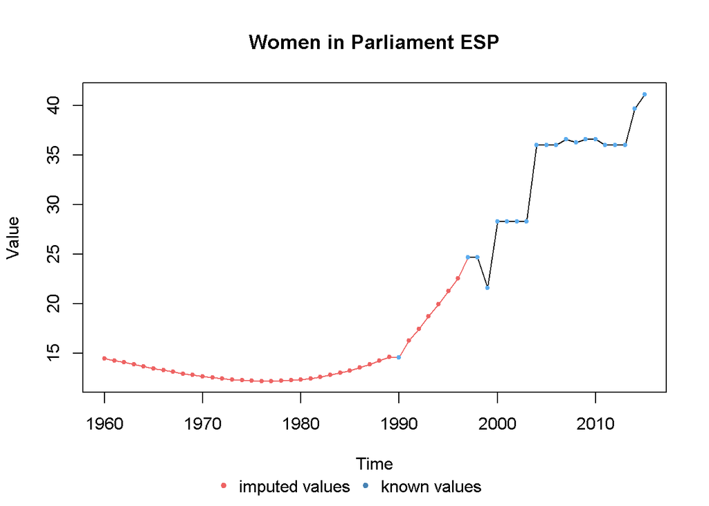

```r
parliaments <- sqldf('select Year, Value from ESP_indicators where IndicatorCode == "SG.GEN.PARL.ZS"')
parliaments_na <- rep(NA, 56)
i <- 1
for (year in parliaments$Year){
  parliaments_na[(year-1960+1)] <- parliaments$Value[i]
  i = i + 1
}
parliaments_ts <- ts(data = parliaments_na, start = 1960, end = 2015, frequency = 1)
if(anyNA(parliaments_ts)){
    parliaments_kalman <- na.kalman(parliaments_ts)
} else{
    parliaments_kalman <- parliaments_ts
}
gender_ESP$'seats held by women in national parliaments (%)' <- parliaments_kalman
plotNA.imputations(parliaments_ts, parliaments_kalman, main = "Women in Parliament ESP")
```

1.2 USA

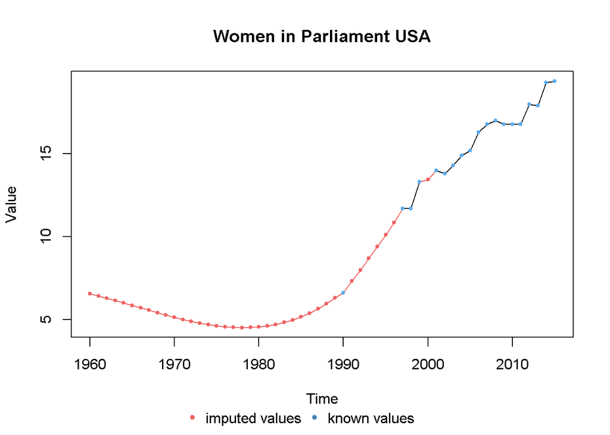

```r
parliaments <- sqldf('select Year, Value from USA_indicators where IndicatorCode == "SG.GEN.PARL.ZS"')
parliaments_na <- rep(NA, 56)
i <- 1
for (year in parliaments$Year){
  parliaments_na[(year-1960+1)] <- parliaments$Value[i]
  i = i + 1
}
parliaments_ts <- ts(data = parliaments_na, start = 1960, end = 2015, frequency = 1)
if(anyNA(parliaments_ts)){
    parliaments_kalman <- na.kalman(parliaments_ts)
} else{
    parliaments_kalman <- parliaments_ts
}
gender_USA$'seats held by women in national parliaments (%)' <- parliaments_kalman
plotNA.imputations(parliaments_ts, parliaments_kalman, main = "Women in Parliament USA")
```

1.3 India

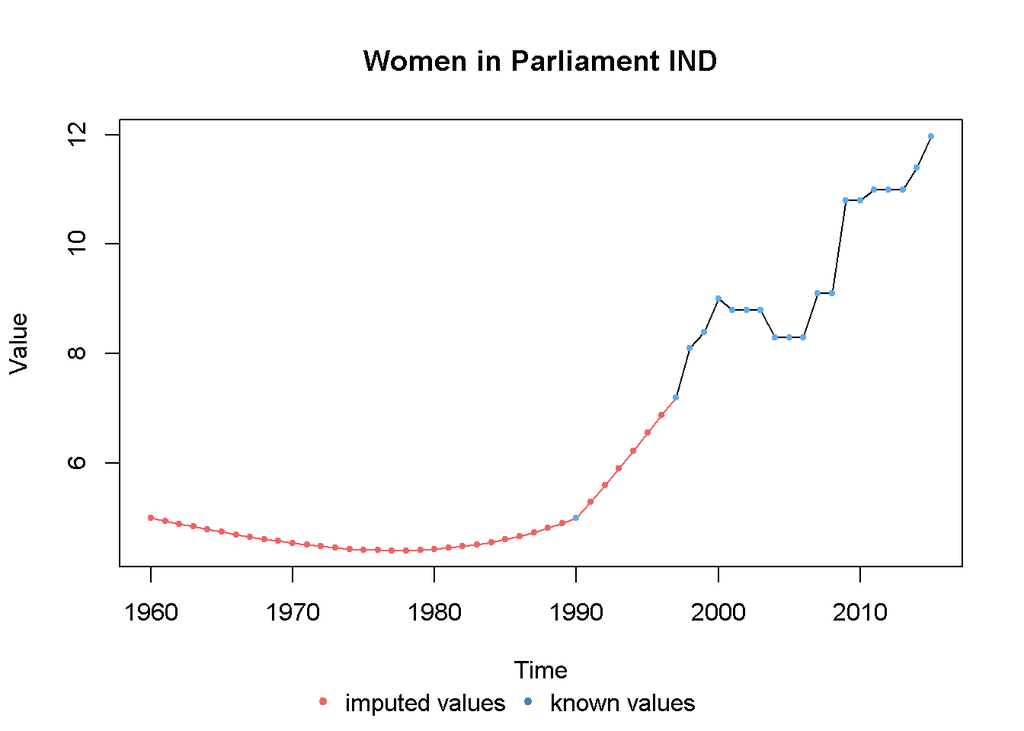

```r
parliaments <- sqldf('select Year, Value from IND_indicators where IndicatorCode == "SG.GEN.PARL.ZS"')
parliaments_na <- rep(NA, 56)
i <- 1
for (year in parliaments$Year){
  parliaments_na[(year-1960+1)] <- parliaments$Value[i]
  i = i + 1
}
parliaments_ts <- ts(data = parliaments_na, start = 1960, end = 2015, frequency = 1)
if(anyNA(parliaments_ts)){
    parliaments_kalman <- na.kalman(parliaments_ts)
} else{
    parliaments_kalman <- parliaments_ts
}
gender_IND$'seats held by women in national parliaments (%)' <- parliaments_kalman
plotNA.imputations(parliaments_ts, parliaments_kalman, main = "Women in Parliament IND")
```

1.4 France

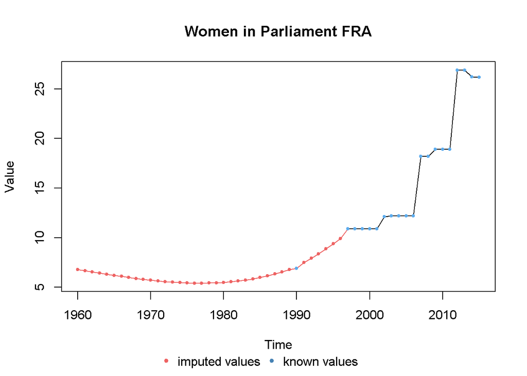

```r
parliaments <- sqldf('select Year, Value from FRA_indicators where IndicatorCode == "SG.GEN.PARL.ZS"')
parliaments_na <- rep(NA, 56)
i <- 1
for (year in parliaments$Year){
  parliaments_na[(year-1960+1)] <- parliaments$Value[i]
  i = i + 1
}
parliaments_ts <- ts(data = parliaments_na, start = 1960, end = 2015, frequency = 1)
if(anyNA(parliaments_ts)){
    parliaments_kalman <- na.kalman(parliaments_ts)
} else{
    parliaments_kalman <- parliaments_ts
}
gender_FRA$'seats held by women in national parliaments (%)' <- parliaments_kalman
plotNA.imputations(parliaments_ts, parliaments_kalman, main = "Women in Parliament FRA")
```

1.5 China

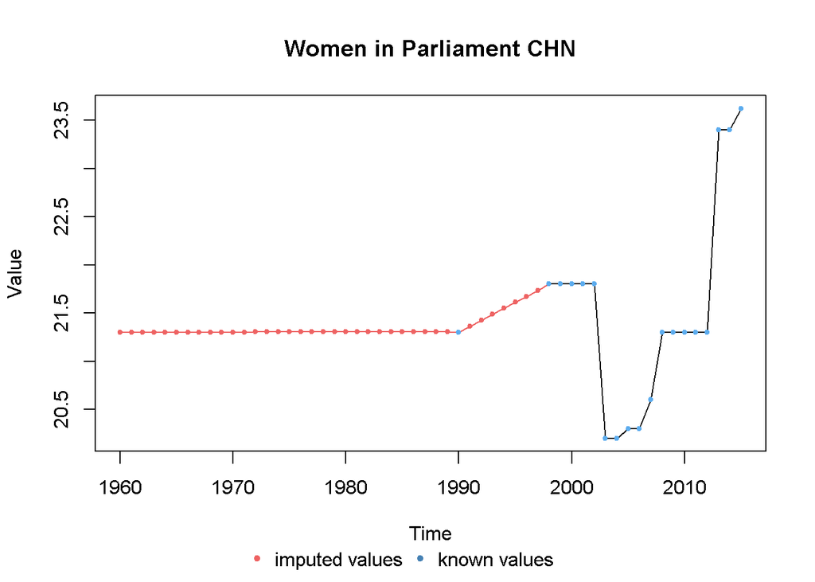

```r
parliaments <- sqldf('select Year, Value from CHN_indicators where IndicatorCode == "SG.GEN.PARL.ZS"')
parliaments_na <- rep(NA, 56)
i <- 1
for (year in parliaments$Year){
  parliaments_na[(year-1960+1)] <- parliaments$Value[i]
  i = i + 1
}
parliaments_ts <- ts(data = parliaments_na, start = 1960, end = 2015, frequency = 1)
if(anyNA(parliaments_ts)){
    parliaments_kalman <- na.kalman(parliaments_ts)
} else{
    parliaments_kalman <- parliaments_ts
}
gender_CHN$'seats held by women in national parliaments (%)' <- parliaments_kalman
plotNA.imputations(parliaments_ts, parliaments_kalman, main = "Women in Parliament CHN")
```

1.6 World

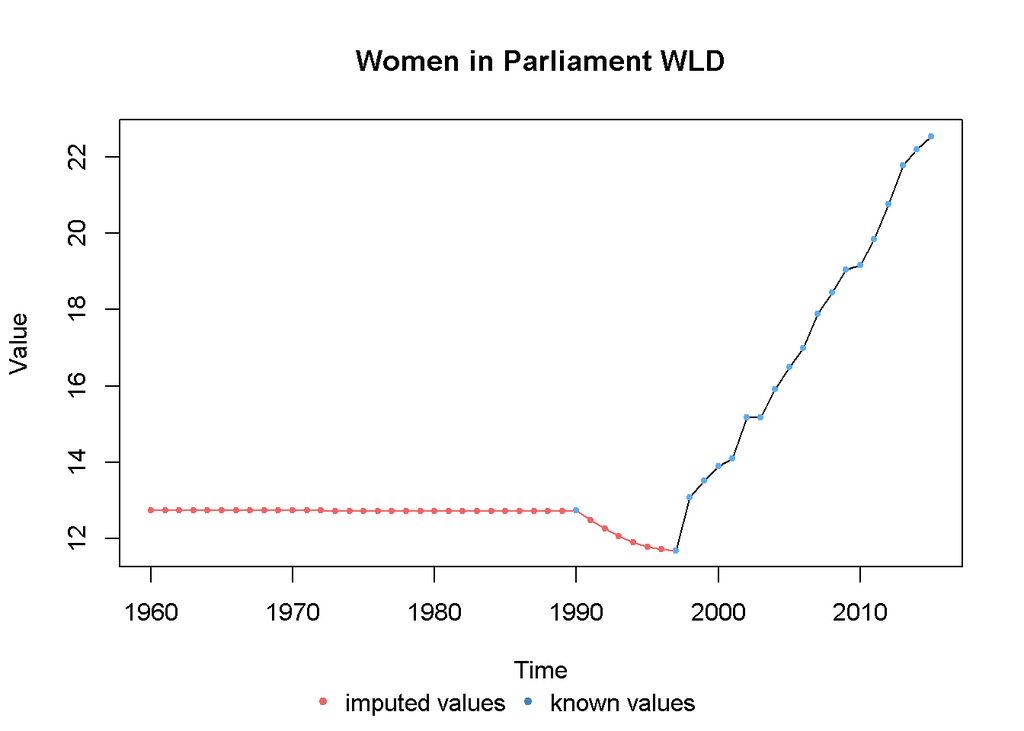

```r
parliaments <- sqldf('select Year, Value from WLD_indicators where IndicatorCode == "SG.GEN.PARL.ZS"')
parliaments_na <- rep(NA, 56)
i <- 1
for (year in parliaments$Year){
  parliaments_na[(year-1960+1)] <- parliaments$Value[i]
  i = i + 1
}
parliaments_ts <- ts(data = parliaments_na, start = 1960, end = 2015, frequency = 1)
if(anyNA(parliaments_ts)){
    parliaments_kalman <- na.kalman(parliaments_ts)
} else{
    parliaments_kalman <- parliaments_ts
}
gender_WLD$'seats held by women in national parliaments (%)' <- parliaments_kalman
plotNA.imputations(parliaments_ts, parliaments_kalman, main = "Women in Parliament WLD")
```

1.7 All

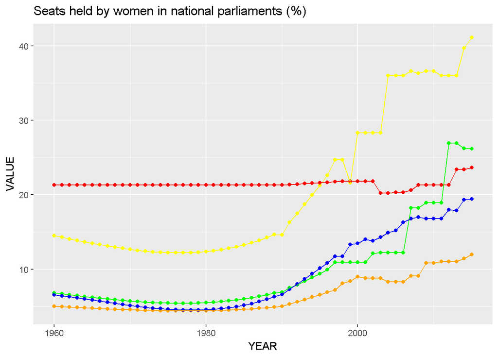

```r
ggplot() +
geom_point(data = gender_ESP, aes(x = gender_ESP$Year, y = gender_ESP$`seats held by women in national parliaments (%)`), color = "yellow") + geom_point(data = gender_CHN, aes(x = gender_CHN$Year, y = gender_CHN$`seats held by women in national parliaments (%)`), color = "red") + geom_point(data = gender_IND, aes(x = gender_IND$Year, y = gender_IND$`seats held by women in national parliaments (%)`), color = "orange") + geom_point(data = gender_FRA, aes(x = gender_FRA$Year, y = gender_FRA$`seats held by women in national parliaments (%)`), color = "green") + geom_point(data = gender_USA, aes(x = gender_USA$Year, y = gender_USA$`seats held by women in national parliaments (%)`), color = "blue") + geom_line(data = gender_ESP, aes(x = gender_ESP$Year, y = gender_ESP$`seats held by women in national parliaments (%)`), color = "yellow") + geom_line(data = gender_CHN, aes(x = gender_CHN$Year, y = gender_CHN$`seats held by women in national parliaments (%)`), color = "red") + geom_line(data = gender_IND, aes(x = gender_IND$Year, y = gender_IND$`seats held by women in national parliaments (%)`), color = "orange") + geom_line(data = gender_FRA, aes(x = gender_FRA$Year, y = gender_FRA$`seats held by women in national parliaments (%)`), color = "green") + geom_line(data = gender_USA, aes(x = gender_USA$Year, y = gender_USA$`seats held by women in national parliaments (%)`), color = "blue") + ggtitle("Seats held by women in national parliaments (%)") + xlab('YEAR') + ylab('VALUE') + theme(legend.position = "top")  + scale_fill_discrete(name = "Country", labels = c("ESP", "CHN", "IND", "FRA", "USA"))
```

2. Gross enrolment ratio, secondary, gender parity index (GPI) 2.1 Spain

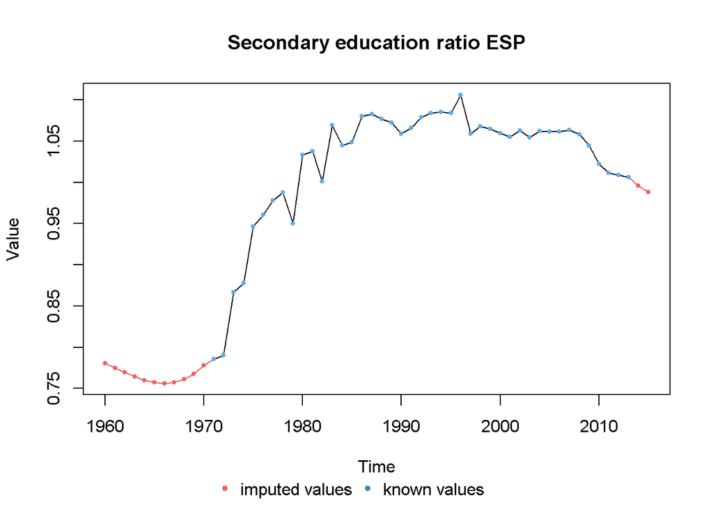

```r
secondary <- sqldf('select Year, Value from ESP_indicators where IndicatorCode == "SE.ENR.SECO.FM.ZS"')
secondary_na <- rep(NA, 56)
i <- 1
for (year in secondary$Year){
  secondary_na[(year-1960+1)] <- secondary$Value[i]
  i = i + 1
}
secondary_ts <- ts(data = secondary_na, start = 1960, end = 2015, frequency = 1)
if(anyNA(secondary_ts)){
    secondary_kalman <- na.kalman(secondary_ts)
} else{
    secondary_kalman <- secondary_ts
}
gender_ESP$'Gross enrolment ratio, secondary, gender parity index (GPI)' <- secondary_kalman
plotNA.imputations(secondary_ts, secondary_kalman, main = "Secondary education ratio ESP")
```

2.2 USA

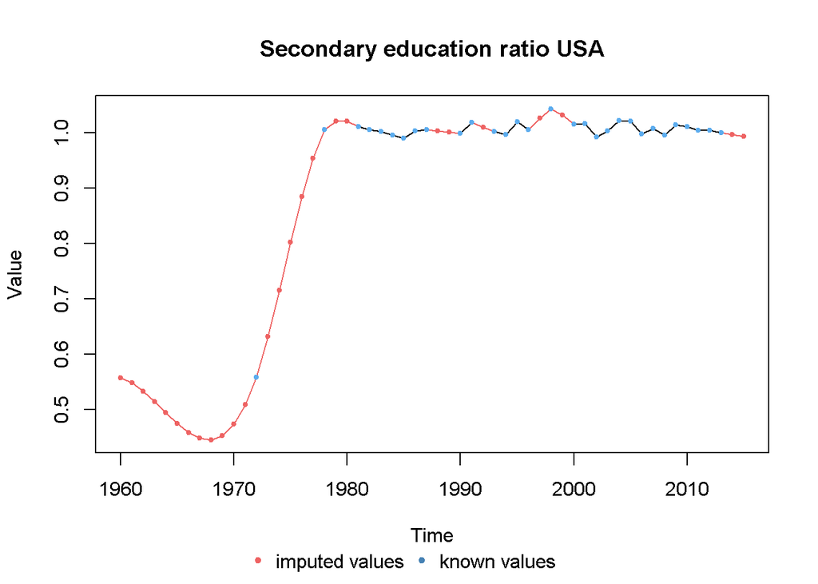

```r
secondary <- sqldf('select Year, Value from USA_indicators where IndicatorCode == "SE.ENR.SECO.FM.ZS"')
secondary_na <- rep(NA, 56)
i <- 1
for (year in secondary$Year){
  secondary_na[(year-1960+1)] <- secondary$Value[i]
  i = i + 1
}
secondary_ts <- ts(data = secondary_na, start = 1960, end = 2015, frequency = 1)
if(anyNA(secondary_ts)){
    secondary_kalman <- na.kalman(secondary_ts)
} else{
    secondary_kalman <- secondary_ts
}
gender_USA$'Gross enrolment ratio, secondary, gender parity index (GPI)' <- secondary_kalman
plotNA.imputations(secondary_ts, secondary_kalman, main = "Secondary education ratio USA")
```

2.3 India

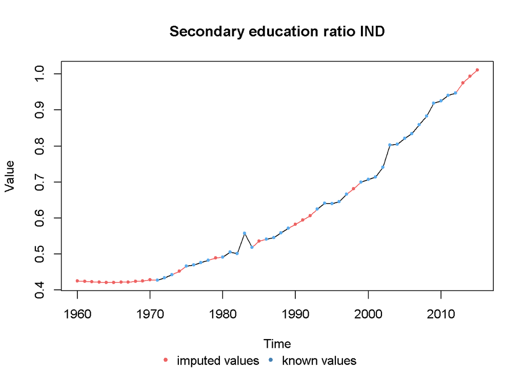

```r
secondary <- sqldf('select Year, Value from IND_indicators where IndicatorCode == "SE.ENR.SECO.FM.ZS"')
secondary_na <- rep(NA, 56)
i <- 1
for (year in secondary$Year){
  secondary_na[(year-1960+1)] <- secondary$Value[i]
  i = i + 1
}
secondary_ts <- ts(data = secondary_na, start = 1960, end = 2015, frequency = 1)
if(anyNA(secondary_ts)){
    secondary_kalman <- na.kalman(secondary_ts)
} else{
    secondary_kalman <- secondary_ts
}
gender_IND$'Gross enrolment ratio, secondary, gender parity index (GPI)' <- secondary_kalman
plotNA.imputations(secondary_ts, secondary_kalman, main = "Secondary education ratio IND")
```

2.4 France

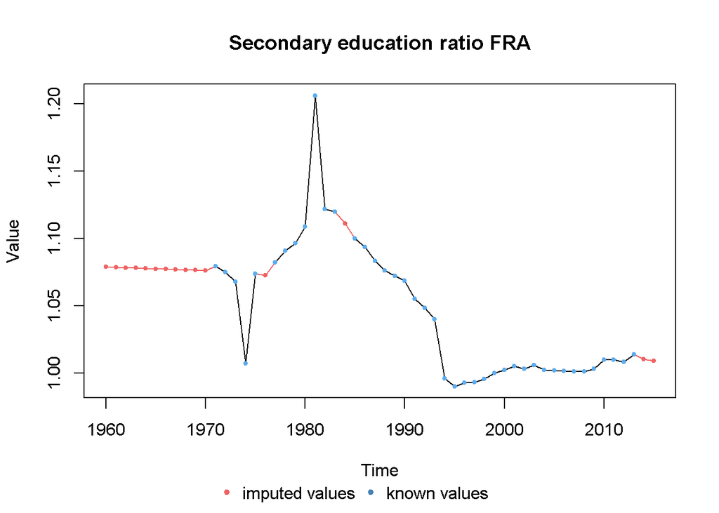

```r
secondary <- sqldf('select Year, Value from FRA_indicators where IndicatorCode == "SE.ENR.SECO.FM.ZS"')
secondary_na <- rep(NA, 56)
i <- 1
for (year in secondary$Year){
  secondary_na[(year-1960+1)] <- secondary$Value[i]
  i = i + 1
}
secondary_ts <- ts(data = secondary_na, start = 1960, end = 2015, frequency = 1)
if(anyNA(secondary_ts)){
    secondary_kalman <- na.kalman(secondary_ts)
} else{
    secondary_kalman <- secondary_ts
}
gender_FRA$'Gross enrolment ratio, secondary, gender parity index (GPI)' <- secondary_kalman
plotNA.imputations(secondary_ts, secondary_kalman, main = "Secondary education ratio FRA")
```

2.5 China

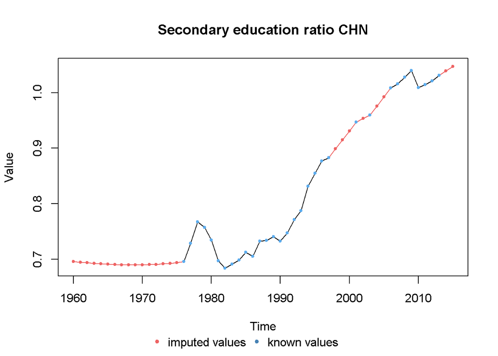

```r
secondary <- sqldf('select Year, Value from CHN_indicators where IndicatorCode == "SE.ENR.SECO.FM.ZS"')
secondary_na <- rep(NA, 56)
i <- 1
for (year in secondary$Year){
  secondary_na[(year-1960+1)] <- secondary$Value[i]
  i = i + 1
}
secondary_ts <- ts(data = secondary_na, start = 1960, end = 2015, frequency = 1)
if(anyNA(secondary_ts)){
    secondary_kalman <- na.kalman(secondary_ts)
} else{
    secondary_kalman <- secondary_ts
}
gender_CHN$'Gross enrolment ratio, secondary, gender parity index (GPI)' <- secondary_kalman
plotNA.imputations(secondary_ts, secondary_kalman, main = "Secondary education ratio CHN")
```

2.6 World

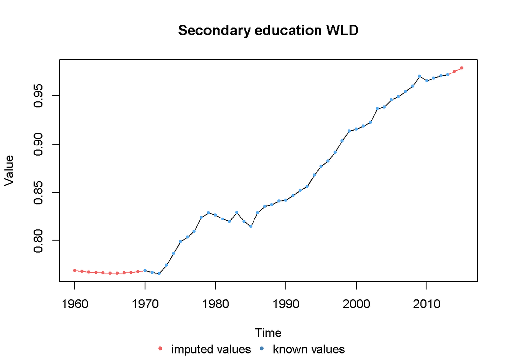

```r
secondary <- sqldf('select Year, Value from WLD_indicators where IndicatorCode == "SE.ENR.SECO.FM.ZS"')
secondary_na <- rep(NA, 56)
i <- 1
for (year in secondary$Year){
  secondary_na[(year-1960+1)] <- secondary$Value[i]
  i = i + 1
}
secondary_ts <- ts(data = secondary_na, start = 1960, end = 2015, frequency = 1)
if(anyNA(secondary_ts)){
    secondary_kalman <- na.kalman(secondary_ts)
} else{
    secondary_kalman <- secondary_ts
}
gender_WLD$'Gross enrolment ratio, secondary, gender parity index (GPI)' <- secondary_kalman
plotNA.imputations(secondary_ts, secondary_kalman, main = "Secondary education WLD")
```

2.7 All

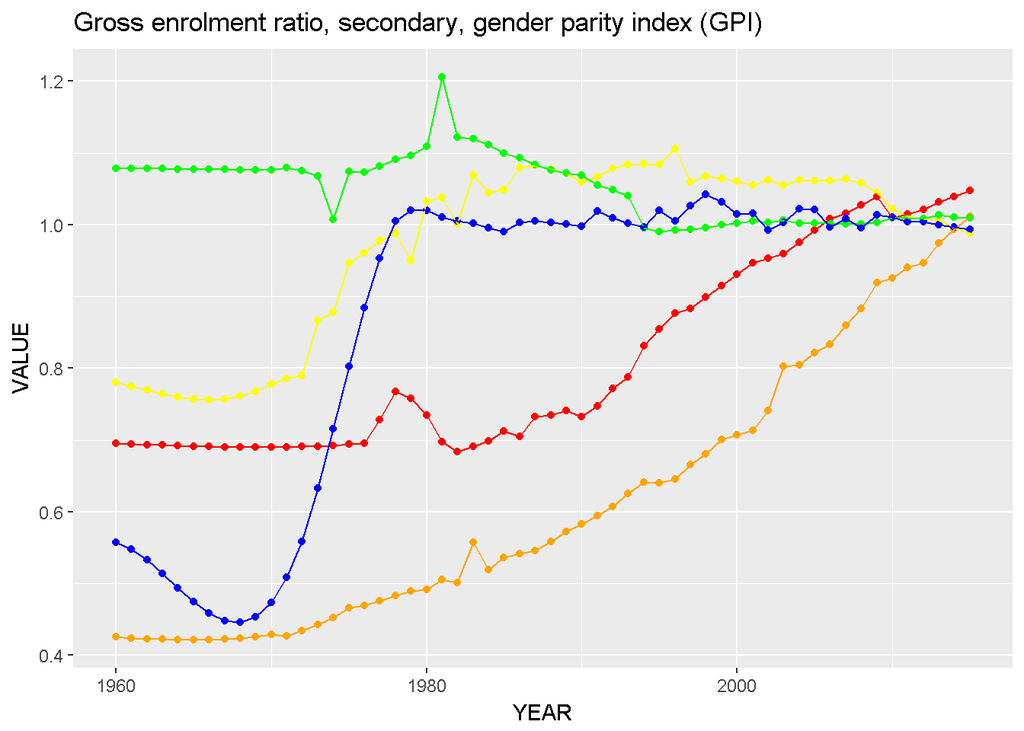

```r
ggplot() +
geom_point(data = gender_ESP, aes(x = gender_ESP$Year, y = gender_ESP$`Gross enrolment ratio, secondary, gender parity index (GPI)`), color = "yellow") + geom_point(data = gender_CHN, aes(x = gender_CHN$Year, y = gender_CHN$`Gross enrolment ratio, secondary, gender parity index (GPI)`), color = "red") + geom_point(data = gender_IND, aes(x = gender_IND$Year, y = gender_IND$`Gross enrolment ratio, secondary, gender parity index (GPI)`), color = "orange") + geom_point(data = gender_FRA, aes(x = gender_FRA$Year, y = gender_FRA$`Gross enrolment ratio, secondary, gender parity index (GPI)`), color = "green") + geom_point(data = gender_USA, aes(x = gender_USA$Year, y = gender_USA$`Gross enrolment ratio, secondary, gender parity index (GPI)`), color = "blue") + geom_line(data = gender_ESP, aes(x = gender_ESP$Year, y = gender_ESP$`Gross enrolment ratio, secondary, gender parity index (GPI)`), color = "yellow") + geom_line(data = gender_CHN, aes(x = gender_CHN$Year, y = gender_CHN$`Gross enrolment ratio, secondary, gender parity index (GPI)`), color = "red") + geom_line(data = gender_IND, aes(x = gender_IND$Year, y = gender_IND$`Gross enrolment ratio, secondary, gender parity index (GPI)`), color = "orange") + geom_line(data = gender_FRA, aes(x = gender_FRA$Year, y = gender_FRA$`Gross enrolment ratio, secondary, gender parity index (GPI)`), color = "green") + geom_line(data = gender_USA, aes(x = gender_USA$Year, y = gender_USA$`Gross enrolment ratio, secondary, gender parity index (GPI)`), color = "blue") + ggtitle("Gross enrolment ratio, secondary, gender parity index (GPI)") + xlab('YEAR') + ylab('VALUE') + theme(legend.position = "top")  + scale_fill_discrete(name = "Country", labels = c("ESP", "CHN", "IND", "FRA", "USA"))
```

3. Adolescent fertility rate (births per 1,000 women ages 15-19) 3.1 Spain

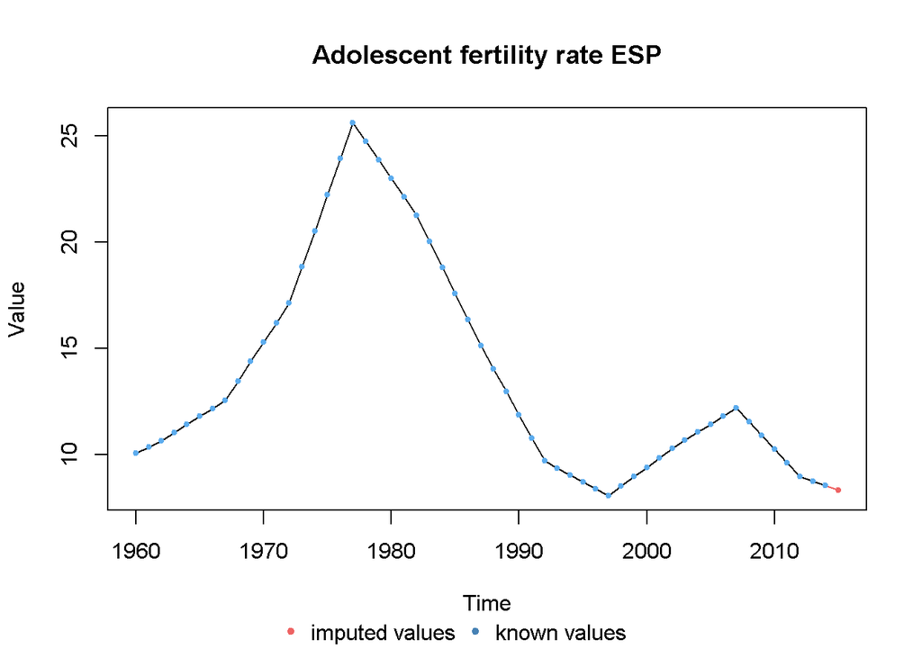

```r
fertility <- sqldf('select Year, Value from ESP_indicators where IndicatorCode == "SP.ADO.TFRT"')
fertility_na <- rep(NA, 56)
i <- 1
for (year in fertility$Year){
  fertility_na[(year-1960+1)] <- fertility$Value[i]
  i = i + 1
}
fertility_ts <- ts(data = fertility_na, start = 1960, end = 2015, frequency = 1)
if(anyNA(fertility_ts)){
    fertility_kalman <- na.kalman(fertility_ts)
} else{
    fertility_kalman <- fertility_ts
}
gender_ESP$'Adolescent fertility rate (births per 1,000 women ages 15-19)' <- fertility_kalman
plotNA.imputations(fertility_ts, fertility_kalman, main = "Adolescent fertility rate ESP")
```

3.2 USA

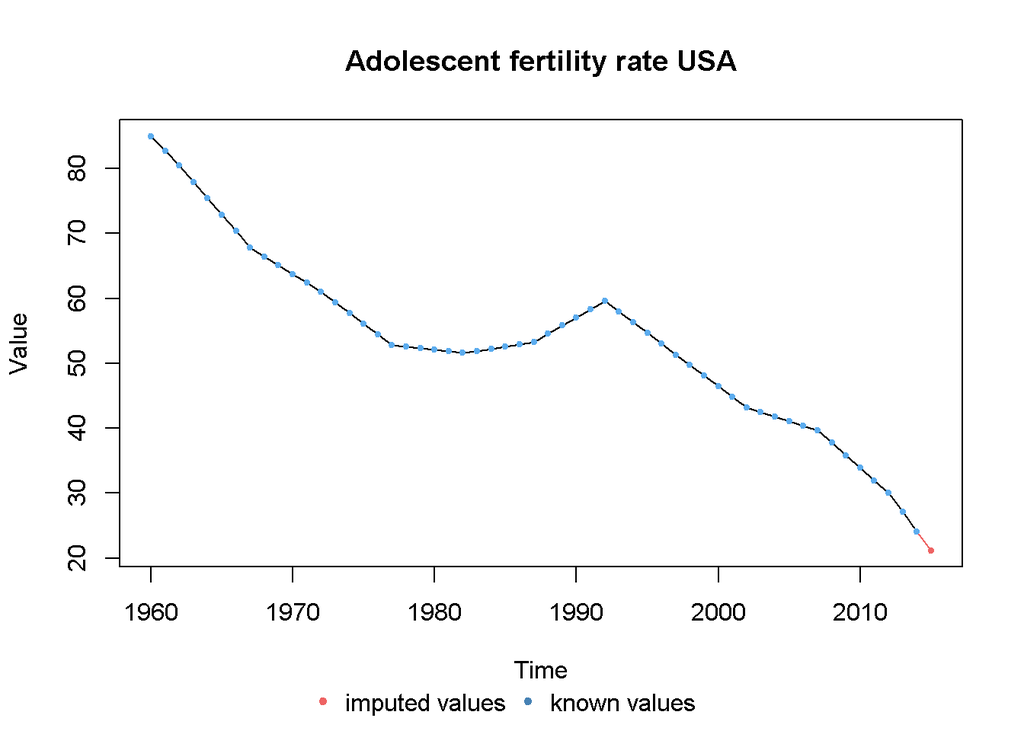

```r
fertility <- sqldf('select Year, Value from USA_indicators where IndicatorCode == "SP.ADO.TFRT"')
fertility_na <- rep(NA, 56)
i <- 1
for (year in fertility$Year){
  fertility_na[(year-1960+1)] <- fertility$Value[i]
  i = i + 1
}
fertility_ts <- ts(data = fertility_na, start = 1960, end = 2015, frequency = 1)
if(anyNA(fertility_ts)){
    fertility_kalman <- na.kalman(fertility_ts)
} else{
    fertility_kalman <- fertility_ts
}
gender_USA$'Adolescent fertility rate (births per 1,000 women ages 15-19)' <- fertility_kalman
plotNA.imputations(fertility_ts, fertility_kalman, main = "Adolescent fertility rate USA")
```

3.3 India

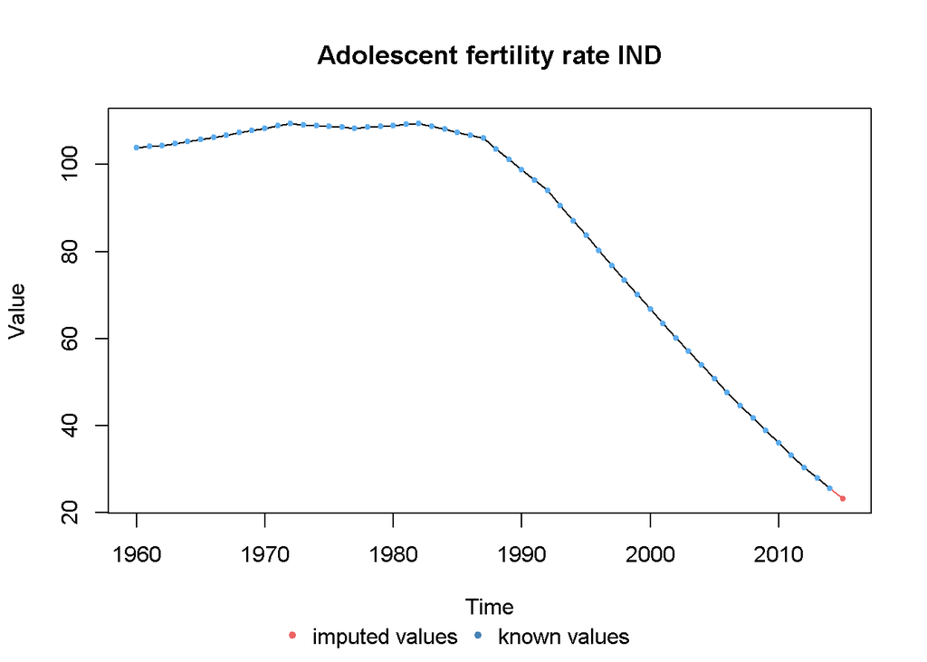

```r
fertility <- sqldf('select Year, Value from IND_indicators where IndicatorCode == "SP.ADO.TFRT"')
fertility_na <- rep(NA, 56)
i <- 1
for (year in fertility$Year){
  fertility_na[(year-1960+1)] <- fertility$Value[i]
  i = i + 1
}
fertility_ts <- ts(data = fertility_na, start = 1960, end = 2015, frequency = 1)
if(anyNA(fertility_ts)){
    fertility_kalman <- na.kalman(fertility_ts)
} else{
    fertility_kalman <- fertility_ts
}
gender_IND$'Adolescent fertility rate (births per 1,000 women ages 15-19)' <- fertility_kalman
plotNA.imputations(fertility_ts, fertility_kalman, main = "Adolescent fertility rate IND")
```

3.4 France

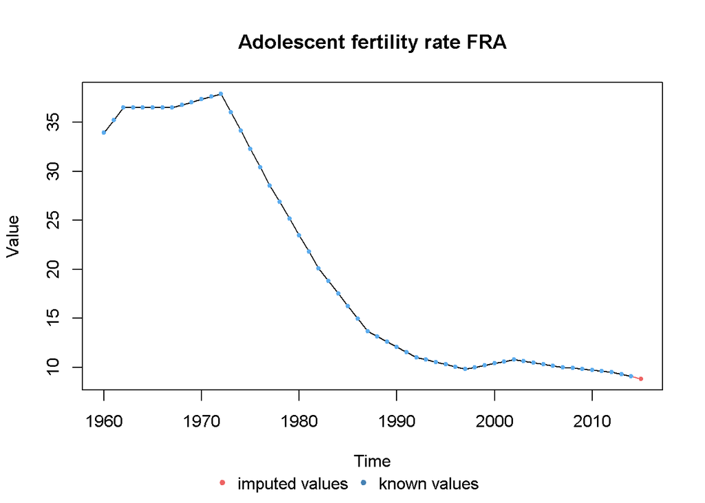

```r
fertility <- sqldf('select Year, Value from FRA_indicators where IndicatorCode == "SP.ADO.TFRT"')
fertility_na <- rep(NA, 56)
i <- 1
for (year in fertility$Year){
  fertility_na[(year-1960+1)] <- fertility$Value[i]
  i = i + 1
}
fertility_ts <- ts(data = fertility_na, start = 1960, end = 2015, frequency = 1)
if(anyNA(fertility_ts)){
    fertility_kalman <- na.kalman(fertility_ts)
} else{
    fertility_kalman <- fertility_ts
}
gender_FRA$'Adolescent fertility rate (births per 1,000 women ages 15-19)' <- fertility_kalman
plotNA.imputations(fertility_ts, fertility_kalman, main = "Adolescent fertility rate FRA")
```

3.5 China

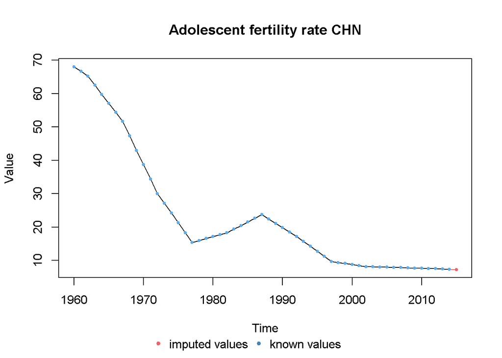

```r
fertility <- sqldf('select Year, Value from CHN_indicators where IndicatorCode == "SP.ADO.TFRT"')
fertility_na <- rep(NA, 56)
i <- 1
for (year in fertility$Year){
  fertility_na[(year-1960+1)] <- fertility$Value[i]
  i = i + 1
}
fertility_ts <- ts(data = fertility_na, start = 1960, end = 2015, frequency = 1)
if(anyNA(fertility_ts)){
    fertility_kalman <- na.kalman(fertility_ts)
} else{
    fertility_kalman <- fertility_ts
}
gender_CHN$'Adolescent fertility rate (births per 1,000 women ages 15-19)' <- fertility_kalman
plotNA.imputations(fertility_ts, fertility_kalman, main = "Adolescent fertility rate CHN")
```

3.6 World

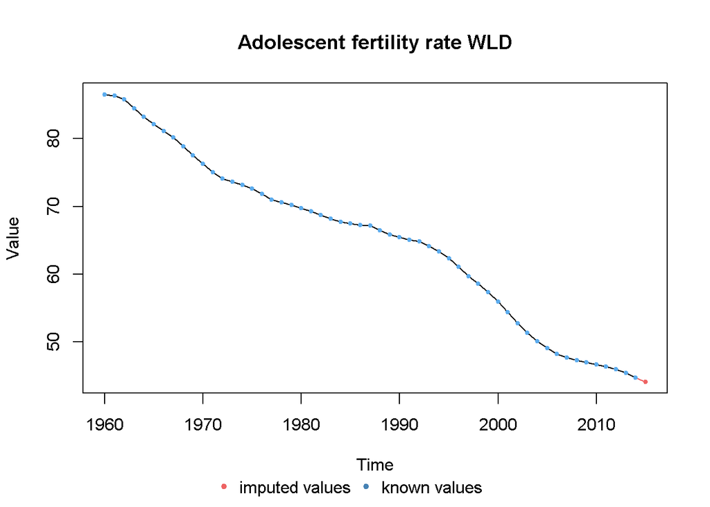

```r
fertility <- sqldf('select Year, Value from WLD_indicators where IndicatorCode == "SP.ADO.TFRT"')
fertility_na <- rep(NA, 56)
i <- 1
for (year in fertility$Year){
  fertility_na[(year-1960+1)] <- fertility$Value[i]
  i = i + 1
}
fertility_ts <- ts(data = fertility_na, start = 1960, end = 2015, frequency = 1)
if(anyNA(fertility_ts)){
    fertility_kalman <- na.kalman(fertility_ts)
} else{
    fertility_kalman <- fertility_ts
}
gender_WLD$'Adolescent fertility rate (births per 1,000 women ages 15-19)' <- fertility_kalman
plotNA.imputations(fertility_ts, fertility_kalman, main = "Adolescent fertility rate WLD")
```

1.7 All

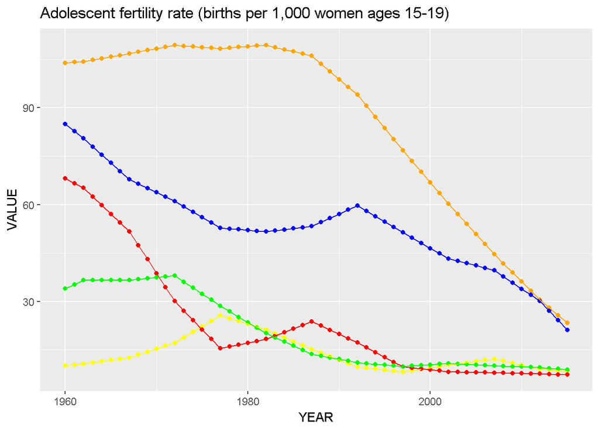

```r
ggplot() +
geom_point(data = gender_ESP, aes(x = gender_ESP$Year, y = gender_ESP$`Adolescent fertility rate (births per 1,000 women ages 15-19)`), color = "yellow") + geom_point(data = gender_CHN, aes(x = gender_CHN$Year, y = gender_CHN$`Adolescent fertility rate (births per 1,000 women ages 15-19)`), color = "red") + geom_point(data = gender_IND, aes(x = gender_IND$Year, y = gender_IND$`Adolescent fertility rate (births per 1,000 women ages 15-19)`), color = "orange") + geom_point(data = gender_FRA, aes(x = gender_FRA$Year, y = gender_FRA$`Adolescent fertility rate (births per 1,000 women ages 15-19)`), color = "green") + geom_point(data = gender_USA, aes(x = gender_USA$Year, y = gender_USA$`Adolescent fertility rate (births per 1,000 women ages 15-19)`), color = "blue") + geom_line(data = gender_ESP, aes(x = gender_ESP$Year, y = gender_ESP$`Adolescent fertility rate (births per 1,000 women ages 15-19)`), color = "yellow") + geom_line(data = gender_CHN, aes(x = gender_CHN$Year, y = gender_CHN$`Adolescent fertility rate (births per 1,000 women ages 15-19)`), color = "red") + geom_line(data = gender_IND, aes(x = gender_IND$Year, y = gender_IND$`Adolescent fertility rate (births per 1,000 women ages 15-19)`), color = "orange") + geom_line(data = gender_FRA, aes(x = gender_FRA$Year, y = gender_FRA$`Adolescent fertility rate (births per 1,000 women ages 15-19)`), color = "green") + geom_line(data = gender_USA, aes(x = gender_USA$Year, y = gender_USA$`Adolescent fertility rate (births per 1,000 women ages 15-19)`), color = "blue") + ggtitle("Adolescent fertility rate (births per 1,000 women ages 15-19)") + xlab('YEAR') + ylab('VALUE') + theme(legend.position = "top")  + scale_fill_discrete(name = "Country", labels = c("ESP", "CHN", "IND", "FRA", "USA"))
```

## CORRELATIONS

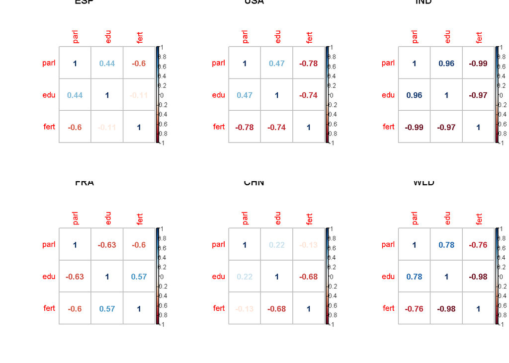

```r
  gender_ESP_temp <- gender_ESP
  colnames(gender_ESP_temp)[colnames(gender_ESP_temp)=="seats held by women in national parliaments (%)"] <- "parl"
  colnames(gender_ESP_temp)[colnames(gender_ESP_temp)=="Gross enrolment ratio, secondary, gender parity index (GPI)"] <- "edu"
  colnames(gender_ESP_temp)[colnames(gender_ESP_temp)=="Adolescent fertility rate (births per 1,000 women ages 15-19)"] <- "fert"
  ESP_cor = cor(gender_ESP_temp[2:4])

  gender_USA_temp <- gender_USA
  colnames(gender_USA_temp)[colnames(gender_USA_temp)=="seats held by women in national parliaments (%)"] <- "parl"
  colnames(gender_USA_temp)[colnames(gender_USA_temp)=="Gross enrolment ratio, secondary, gender parity index (GPI)"] <- "edu"
  colnames(gender_USA_temp)[colnames(gender_USA_temp)=="Adolescent fertility rate (births per 1,000 women ages 15-19)"] <- "fert"
  USA_cor = cor(gender_USA_temp[2:4])

  gender_IND_temp <- gender_IND
  colnames(gender_IND_temp)[colnames(gender_IND_temp)=="seats held by women in national parliaments (%)"] <- "parl"
  colnames(gender_IND_temp)[colnames(gender_IND_temp)=="Gross enrolment ratio, secondary, gender parity index (GPI)"] <- "edu"
  colnames(gender_IND_temp)[colnames(gender_IND_temp)=="Adolescent fertility rate (births per 1,000 women ages 15-19)"] <- "fert"
  IND_cor = cor(gender_IND_temp[2:4])

  gender_FRA_temp <- gender_FRA
  colnames(gender_FRA_temp)[colnames(gender_FRA_temp)=="seats held by women in national parliaments (%)"] <- "parl"
  colnames(gender_FRA_temp)[colnames(gender_FRA_temp)=="Gross enrolment ratio, secondary, gender parity index (GPI)"] <- "edu"
  colnames(gender_FRA_temp)[colnames(gender_FRA_temp)=="Adolescent fertility rate (births per 1,000 women ages 15-19)"] <- "fert"
  FRA_cor = cor(gender_FRA_temp[2:4])

  gender_CHN_temp <- gender_CHN
  colnames(gender_CHN_temp)[colnames(gender_CHN_temp)=="seats held by women in national parliaments (%)"] <- "parl"
  colnames(gender_CHN_temp)[colnames(gender_CHN_temp)=="Gross enrolment ratio, secondary, gender parity index (GPI)"] <- "edu"
  colnames(gender_CHN_temp)[colnames(gender_CHN_temp)=="Adolescent fertility rate (births per 1,000 women ages 15-19)"] <- "fert"
  CHN_cor = cor(gender_CHN_temp[2:4])

  gender_WLD_temp <- gender_WLD
  colnames(gender_WLD_temp)[colnames(gender_WLD_temp)=="seats held by women in national parliaments (%)"] <- "parl"
  colnames(gender_WLD_temp)[colnames(gender_WLD_temp)=="Gross enrolment ratio, secondary, gender parity index (GPI)"] <- "edu"
  colnames(gender_WLD_temp)[colnames(gender_WLD_temp)=="Adolescent fertility rate (births per 1,000 women ages 15-19)"] <- "fert"
  WLD_cor = cor(gender_WLD_temp[2:4])

  par(mfrow=c(2,3))
  corrplot(ESP_cor, method = "number", title = "ESP")
  corrplot(USA_cor, method = "number", title = "USA")
  corrplot(IND_cor, method = "number", title = "IND")
  corrplot(FRA_cor, method = "number", title = "FRA")
  corrplot(CHN_cor, method = "number", title = "CHN")
  corrplot(WLD_cor, method = "number", title = "WLD")
```

ARIMA FIT (SPAIN)

```r
# response time series stationary?
adf.test(gender_ESP$`seats held by women in national parliaments (%)`)
```

```
##
##  Augmented Dickey-Fuller Test
##
## data:  gender_ESP$`seats held by women in national parliaments (%)`
## Dickey-Fuller = -1.572, Lag order = 3, p-value = 0.7472
## alternative hypothesis: stationary
```

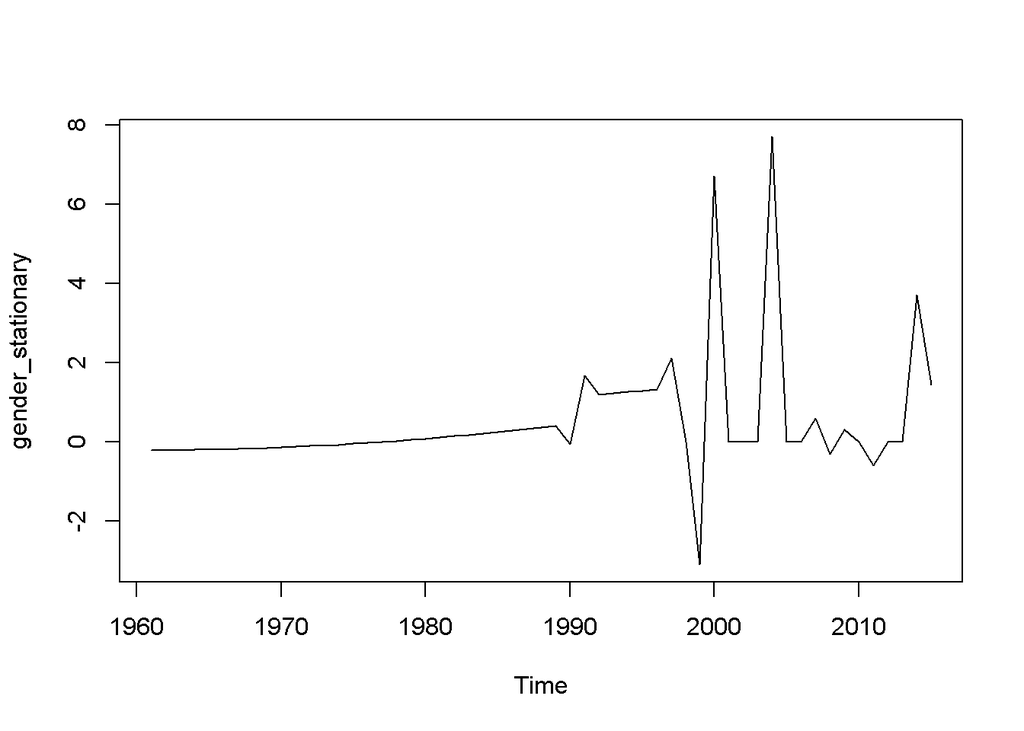

```r
gender_stationary <- diff(gender_ESP$`seats held by women in national parliaments (%)`, differences = 1)
plot(gender_stationary)
```

```r
life.train <- gender_stationary[1:51]
life.test <- gender_stationary[52:55]

#fit ARIMA model
arima.fit <- auto.arima(life.train, stationary = TRUE, seasonal = FALSE)
summary(arima.fit)
```

```
## Series: life.train
## ARIMA(0,0,0) with non-zero mean
##
## Coefficients:
##         mean
##       0.4218
## s.e.  0.2165
##
## sigma^2 estimated as 2.439:  log likelihood=-94.59
## AIC=193.18   AICc=193.43   BIC=197.05
##
## Training set error measures:
##                        ME     RMSE       MAE  MPE MAPE     MASE      ACF1
## Training set 4.463001e-16 1.546221 0.8188919 -Inf  Inf 0.924047 -0.152662
```

[figure not shown]

```r
#Plot to see if there are any patterns in ACF or PACF to choose better p, d, q
tsdisplay(residuals(arima.fit), lag.max=45, main='(1,0,0) Model Residuals')
```

```r
#Look for patterns: maybe a pattern around lag 5?? Fit a new model but I don't know how to compare both
arima.fit2 <- arima(gender_stationary, order = c(1, 0, 5))
summary(arima.fit2)
```

```
##
## Call:
## arima(x = gender_stationary, order = c(1, 0, 5))
##
## Coefficients:
##           ar1      ma1     ma2     ma3     ma4      ma5  intercept
##       -0.0083  -0.1509  0.1472  0.1562  0.8923  -0.4121     0.4985
## s.e.   0.3111   0.3364  0.1006  0.1693  0.3066   0.3121     0.2342
##
## sigma^2 estimated as 1.195:  log likelihood = -88.28,  aic = 192.56
##
## Training set error measures:
##                     ME     RMSE     MAE MPE MAPE      MASE         ACF1
## Training set 0.0140469 1.093252 0.71168 NaN  Inf 0.7555105 -0.006011048
```

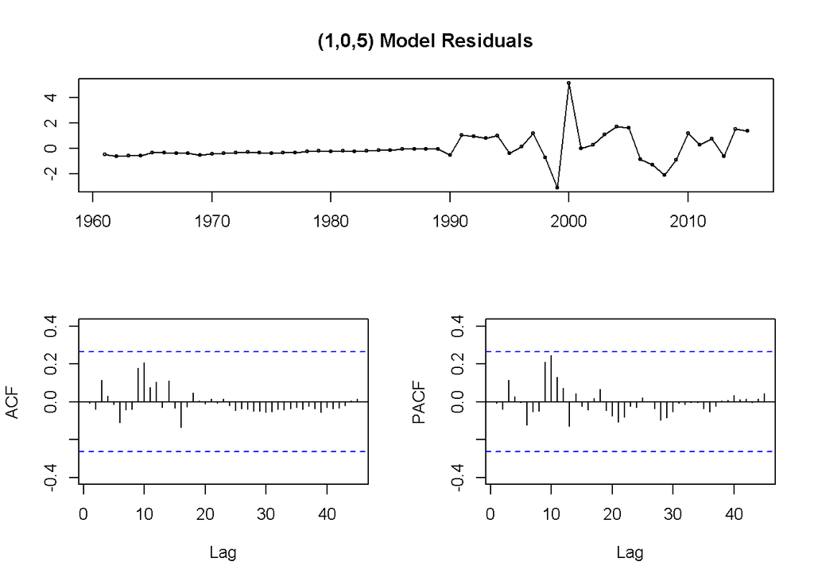

```r
tsdisplay(residuals(arima.fit2), lag.max=45, main='(1,0,5) Model Residuals')
```

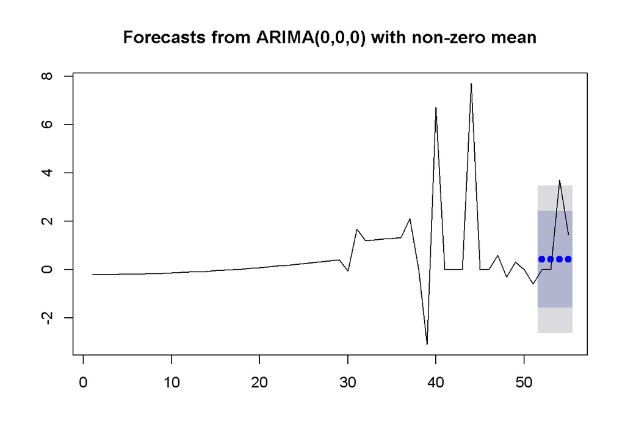

```r
fcast <- forecast(arima.fit, h = 4)
plot(fcast)
lines(ts(gender_stationary))
```

```r
mse(as.numeric(life.test), as.numeric(fcast$mean))
```

```
## [1] 3.036201
```

ARIMA FIT (IND)

```r
# response time series stationary?
adf.test(gender_IND$`Gross enrolment ratio, secondary, gender parity index (GPI)`)
```

```
##
##  Augmented Dickey-Fuller Test
##
## data:  gender_IND$`Gross enrolment ratio, secondary, gender parity index (GPI)`
## Dickey-Fuller = -0.85234, Lag order = 3, p-value = 0.9518
## alternative hypothesis: stationary
```

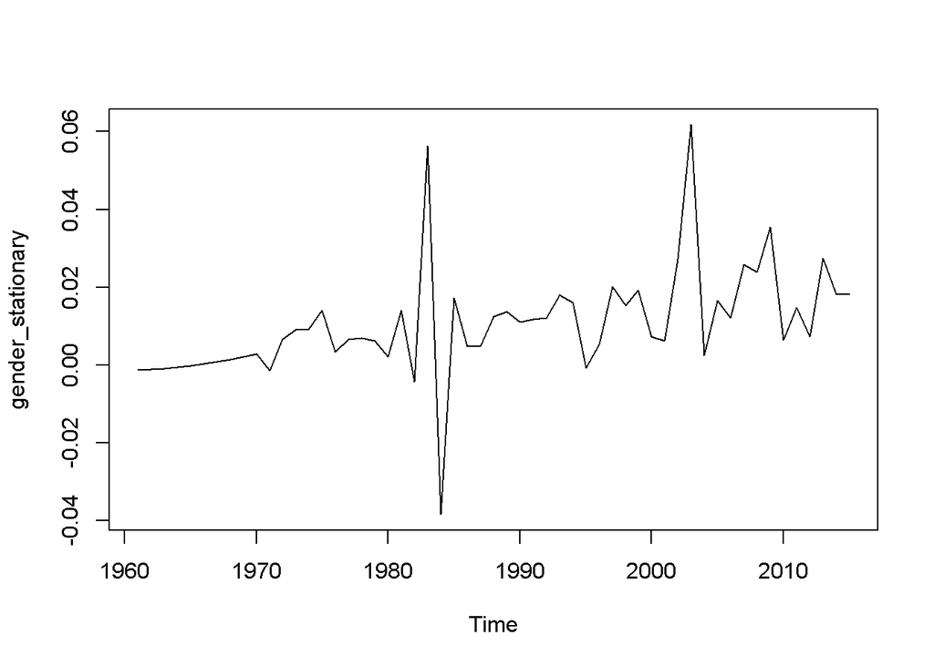

```r
gender_stationary <- diff(gender_IND$`Gross enrolment ratio, secondary, gender parity index (GPI)`, differences = 1)
plot(gender_stationary)
```

```r
life.train <- gender_stationary[1:51]
life.test <- gender_stationary[52:55]

#fit ARIMA model
arima.fit <- auto.arima(life.train, stationary = TRUE, seasonal = FALSE)
summary(arima.fit)
```

```
## Series: life.train
## ARIMA(2,0,2) with non-zero mean
##
## Coefficients:
##          ar1      ar2      ma1     ma2    mean
##       1.1843  -0.2143  -1.5041  0.6519  0.0098
## s.e.  0.2714   0.2660   0.2218  0.1918  0.0063
##
## sigma^2 estimated as 0.0001771:  log likelihood=149.77
## AIC=-287.54   AICc=-285.64   BIC=-275.95
##
## Training set error measures:
##                       ME      RMSE         MAE     MPE     MAPE      MASE
## Training set 0.001628256 0.0126397 0.007999175 117.343 198.6114 0.6959027
##                     ACF1
## Training set -0.04238344
```

[figure not shown]

```r
#Plot to see if there are any patterns in ACF or PACF to choose better p, d, q
tsdisplay(residuals(arima.fit), lag.max=45, main='(1,0,0) Model Residuals')
```

```r
#Look for patterns: maybe a pattern around lag 5?? Fit a new model but I don't know how to compare both
arima.fit2 <- arima(gender_stationary, order = c(1, 0, 5))
summary(arima.fit2)
```

```
##
## Call:
## arima(x = gender_stationary, order = c(1, 0, 5))
##
## Coefficients:
##          ar1      ma1     ma2      ma3     ma4      ma5  intercept
##       0.9482  -1.2528  0.4525  -0.1755  0.2495  -0.0656     0.0094
## s.e.  0.0724   0.1699  0.2252   0.2441  0.1934   0.1687     0.0053
##
## sigma^2 estimated as 0.0001493:  log likelihood = 163.54,  aic = -311.08
##
## Training set error measures:
##                       ME       RMSE         MAE      MPE     MAPE     MASE
## Training set 0.001260174 0.01221829 0.007674813 109.2915 197.5219 0.677752
##                     ACF1
## Training set -0.01578443
```

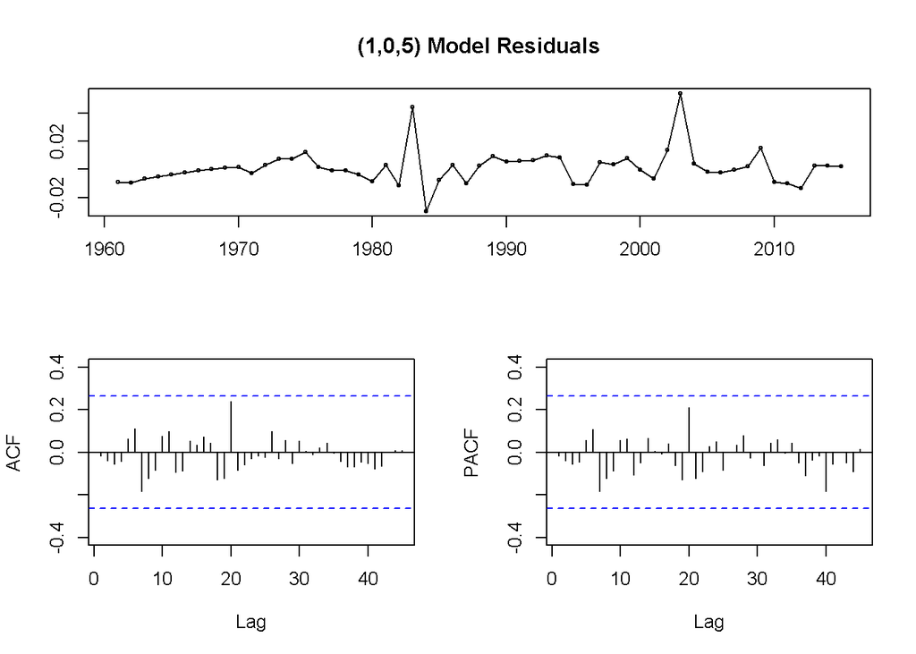

```r
tsdisplay(residuals(arima.fit2), lag.max=45, main='(1,0,5) Model Residuals')
```

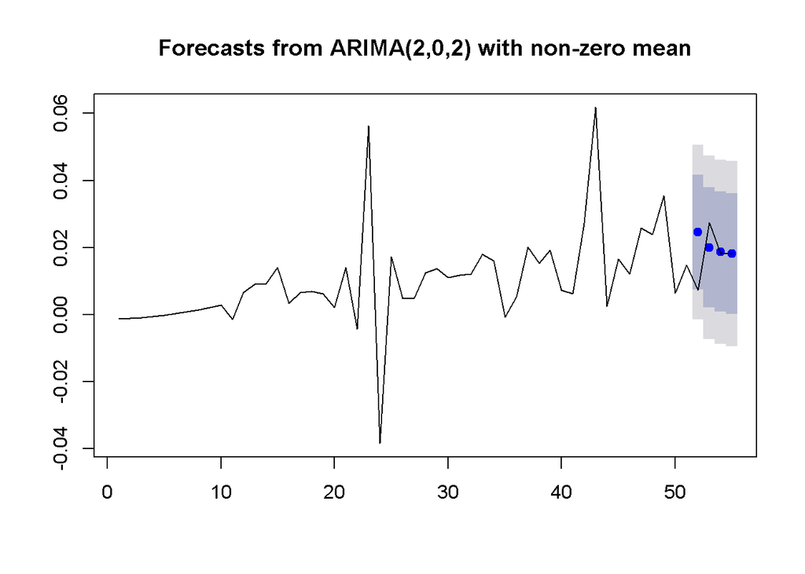

```r
fcast <- forecast(arima.fit, h = 4)
plot(fcast)
lines(ts(gender_stationary))
```

```r
mse(as.numeric(life.test), as.numeric(fcast$mean))
```

```
## [1] 8.813078e-05
```